# **Analyzing the Data in Ford's GoBike Program**

## By Hana Hilmy

## Investigation Overview

> I will do data analysis on the Ford GoBike dataset. To explore the dataset's variables and comprehend the data's connections, I will utilize data visualization packages. This section's investigation progresses from simple univariate relationships to multivariate relationships.

## Dataset Overview

> There are 183,412 bike trips in the dataset with 16 features. However, the dataset contains some missing information. There are only 174,952 bike trips with complete information.
- duration (numeric)
- start time (datetime)
- end time (datetime)
- start station information such as id, name, latitude, longitude (object)
- end station information such as id, name, latitude, longitude (object)
- bike id (numeric)
- user type (categorical): Subscriber or Customer
- member birth year (float)
- member gender (categorical): Male, Female, Other
- bike share (object/binary)

## Duration of Bike Trips in General

> To begin with, I was simply interested as to how many rides were taken in total. The graphic below shows that the peak of rides lasts around 550 seconds.

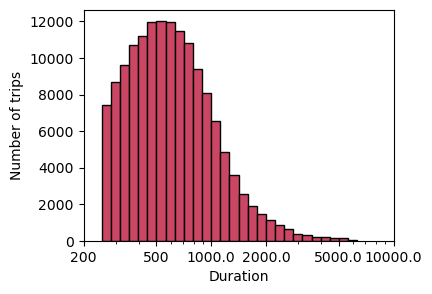

```python
# change graph into log format
duration_filter = df.query('duration_sec < 6000')
log_binsize = 0.05
bins = 10 ** np.arange(2.4, np.log10(duration_filter['duration_sec'].max())+log_binsize, log_binsize)
plt.hist(data = duration_filter, x = 'duration_sec', bins = bins, color='#cb4564', edgecolor='black')
plt.xscale('log')
tick_locs = [200, 500, 1e3, 2e3, 5e3, 1e4]
plt.xticks(tick_locs, tick_locs)
plt.xlabel('Duration')
plt.ylabel('Number of trips')

plt.show()
```

## Distribution of Age in Members in General

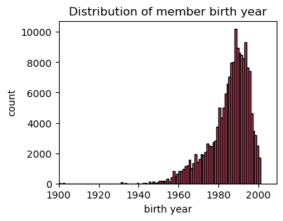

```python
binsize = 1
bins = np.arange(0, df['member_birth_year'].max()+binsize, binsize)
plt.hist(data = df, x = 'member_birth_year', bins = bins, color='#cb4564',edgecolor='black')
plt.title('Distribution of member birth year')
plt.xlabel('birth year')
plt.ylabel('count')
plt.xlim(1900, 2009)
plt.show()
```

## Distribution of Gender in Members in General

> The graph shows that 75% of members (most members) are males then 23% of members are female. The graph shows that the other members are less than 2%.

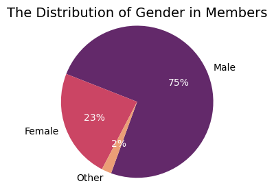

```python
UserTypes_Count = df['member_gender'].value_counts()
UserTypes_Count = UserTypes_Count[:3]
palette=['#63296A','#cb4564', '#eb9e76']
_, _, autotexts = plt.pie(UserTypes_Count[:3], labels = UserTypes_Count.index, autopct='%1.0f%%', radius = 1.2, startangle = 250, colors=palette)
for autotext in autotexts:
    autotext.set_color('white')

plt.title("The Distribution of Gender in Members",fontsize=14)
plt.axis('off');
plt.show()
```

## Distribution of Gender in Members in General

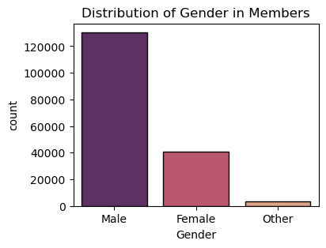

```python
# distribution of gender in members
order = ['Male', 'Female', 'Other']
palette=['#63296A','#cb4564', '#eb9e76']
sb.countplot(data=df, x='member_gender', order=order, edgecolor='black', palette=palette)
plt.title('Distribution of Gender in Members')
plt.xlabel('Gender');
plt.show()
```

## How the 2 Categories Genders and Member Types Influence Duration and Age

> For different user types both are appearing comparative patterns for age and trip duration, however, there is a minor higher age bias for subscribers with longer trip durations. The quantity of longer-duration trips is greater for males, but the proportion is higher for women and others; moreover, others have one more peak at roughly the age of 55 for longer-duration trips.

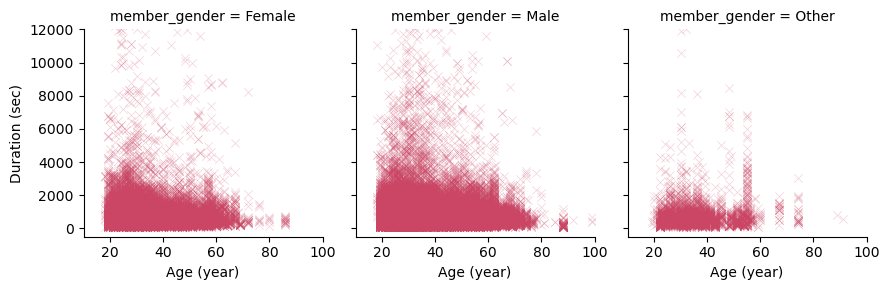

```python
base_color = '#cb4564'

df['age'] = (2019 - df['member_birth_year'])
genders = sb.FacetGrid(data = df, col = 'member_gender', col_wrap = 3, size = 3,
                 xlim = [10, 100], ylim = [-500, 12000])
genders.map(sb.scatterplot, 'age', 'duration_sec', alpha=0.25,color=base_color, marker="x")
genders.set_xlabels('Age (year)')
genders.set_ylabels('Duration (sec)')

plt.show()
```

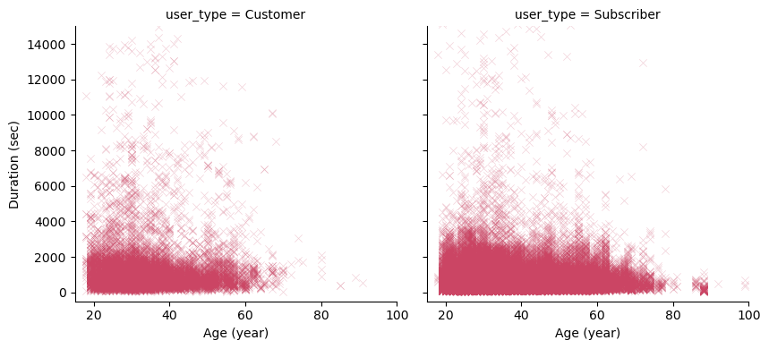

```python
user_types = sb.FacetGrid(data = df, col = 'user_type', col_wrap = 10, size = 4,
                 xlim = [15, 100], ylim = [-500, 15000])
user_types.map(sb.scatterplot, 'age', 'duration_sec', alpha=0.25,color ='#cb4564', marker="x")
user_types.set_xlabels('Age (year)')
user_types.set_ylabels('Duration (sec)')

plt.show()
```

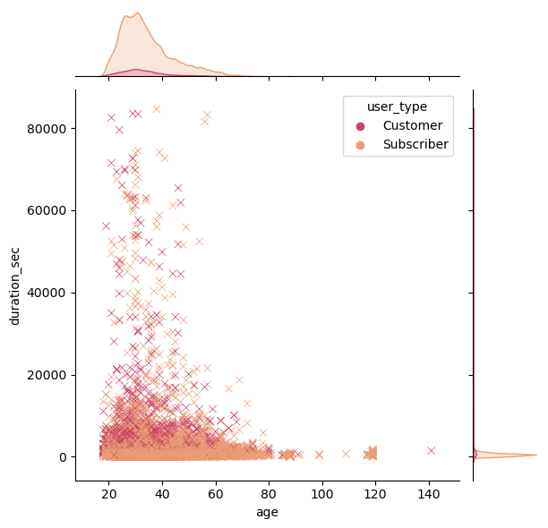

```python
ax=sb.jointplot(data=df, x="age",y="duration_sec",hue ="user_type",palette=['#cb4564', '#eb9e76'], marker="x")
ax
plt.show()
```